# Questioning the influence of roots: supplementary data

## Setup and data preparation

## 1. Raw data exploration

Table 1: Summary of invertebrates occurrences and sampling effort

| Taxon | Biological Data Total occurrences | Sampling Effort Sample images | Sampling Effort Mean occurrence per image |
| --- | --- | --- | --- |
| acari | 429 | 264 | 1.62 |
| collembola | 1991 | 444 | 4.48 |
| gastropoda | 994 | 316 | 3.15 |

Note:  
Total unique images analyzed: 541 Total scanner units: 8 Total period units: 7

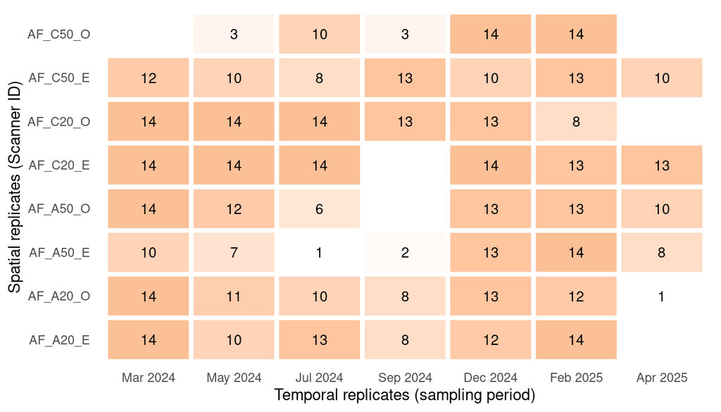

Figure 1: Spatio-temporal sampling effort : total images analyzed per scanner and period

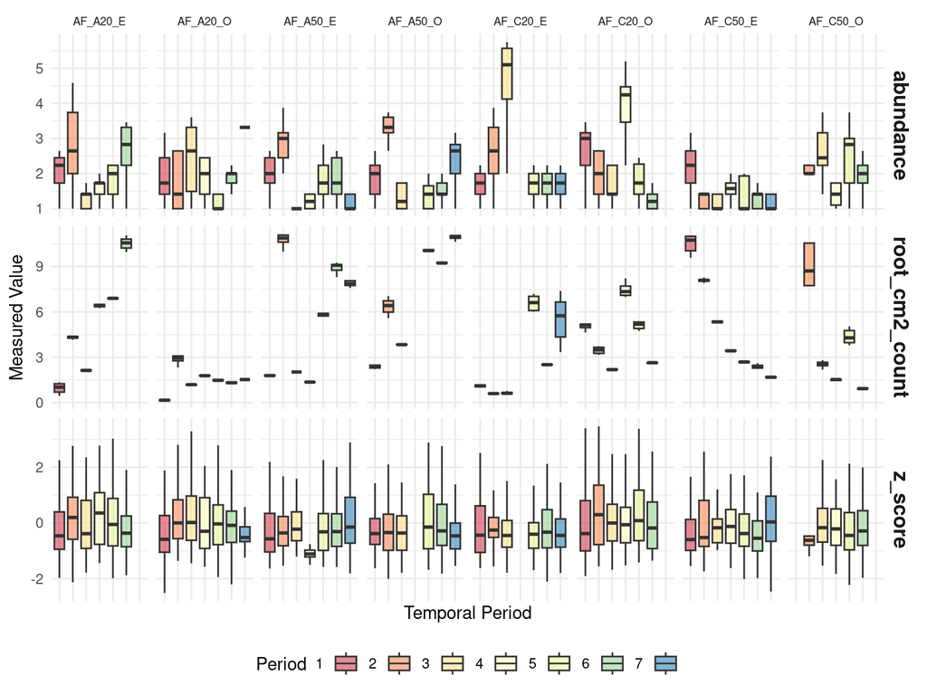

(a) Rows: Biological and Environmental metrics | Columns: Spatial replicates (Scanners)

Figure 2: Replicate-level variability of studied metrics

## 1. The rhizosphere effect: attraction and spatial signature

### **Why use Z-scores instead of simple differences?**

To evaluate whether soil fauna actively select the rhizosphere, we must distinguish between biological attraction and spatial chance. We utilized a standardized selection index ($z$-score) calculated as:

$$z = \frac{Observed - Expected}{SD_{expected}}$$

A simple arithmetic difference ($Observed - Expected$) is statistically flawed for comparing different habitats due to scaling bias. The “randomness” of an animal’s position is dictated by the underlying geometry complexity of the habitat, captured by the integrated spatial sd ($SD_{expected}$). If we rely on unnormalized differences, we encounter two major issues:

- Scale sensitivity: A 1cm deviation is a massive biological signal in a dense, low-sd root system, but merely “statistical noise” in a sparse, high-sd environment.
- Heteroscedasticity: As shown in the following “unnormalized signal” plot, the variance of the raw difference expands as spatial uncertainty increases. This fan shape indicates that the metric’s reliability is inconsistent across the dataset.

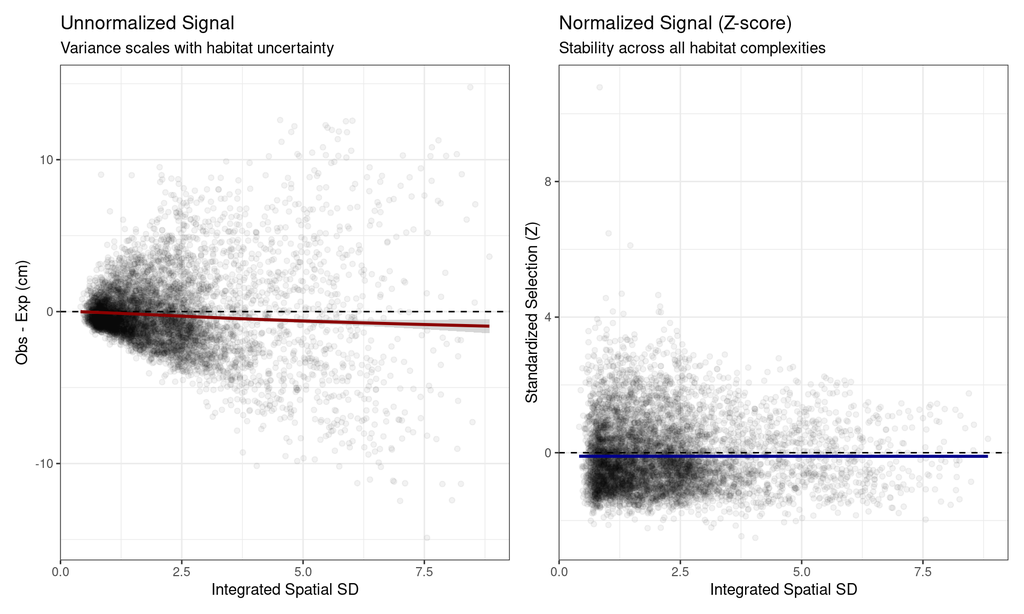

Figure 3: Normalization comparison

The “normalized signal” plot shows that the $z$-score remains more stable across the whole range of spatial complexities. This process tend to filters out stochastic noise and ensuring that a high negative $z$-score consistently indicates a biological “pull” toward the root, regardless of the complexity of the habitat.

## 2. The geometric niche: habitat availability constraint

### **Context**

While attraction is a key driver, the physical presence of roots inherently constrains the available habitat. As root density increases, bulk soil volume diminishes, mathematically increasing the probability of fauna-root encounters regardless of biological preference. To isolate the true “biological signal,” we wanted to model the $z$-score across a root density gradient.

### **Addressing spatial-temporal autocorrelation**

In our experimental setup, root density within a specific scanner over a 7-day period is often stable (see Figure 2). This creates a statistical challenge: if we model every individual occurrence, we treat each one as an independent “choice.” However, occurrences within the same scanner and period are constrained by the same physical architecture. To avoid artificially inflating our degrees of freedom and providing a biased estimate of the “geometric niche,” we performed a sensitivity analysis :

- **Individual-Level Model:** High resolution, but susceptible to Type I errors due to high intra-replicate autocorrelation.
- **Aggregated-Level Model:** data is collapsed to Scanner × Period × Taxon × Root type means. This ensures that each data point represents a unique “habitat state,” forcing the model to look for trends across experimental units rather than individual points.

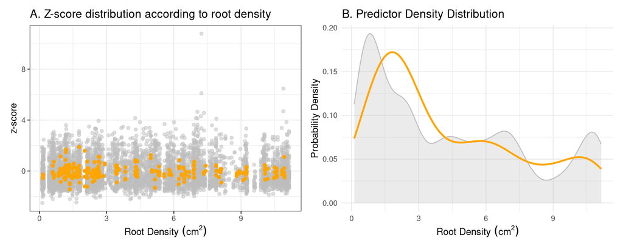

(a) Grey: individual observations | Orange: Replicate averages (aggregated)

Figure 4: Structural impact of data aggregation

The “vertical striping” in Figure 4 (A) highlights the pseudo-replication issue: many fauna share identical root density values. The aggregation process in Figure 4 (B) preserves the experimental gradient while smoothing over-represented low-density zones, providing a more balanced predictor distribution.

### **Distribution choice: Why `scat()`?**

The selection of the scaled $t$-family (`scat()`) was necessitated by the “heavy-tailed” nature of $z$-scores in this system. Ecological data often contain extreme behaviors—individuals that are exceptionally attracted to or repelled by a resource - that create outliers beyond what a standard Gaussian (Normal) distribution can accommodate. As shown in the comparative QQ-plots, the `scat` family accounts for these heavy tails, preventing extreme values from disproportionately pulling the fitted splines.

```
                     df      AIC
mod_gaussian   19.26655 401.1098
mod_aggregated 23.61698 364.4128
```

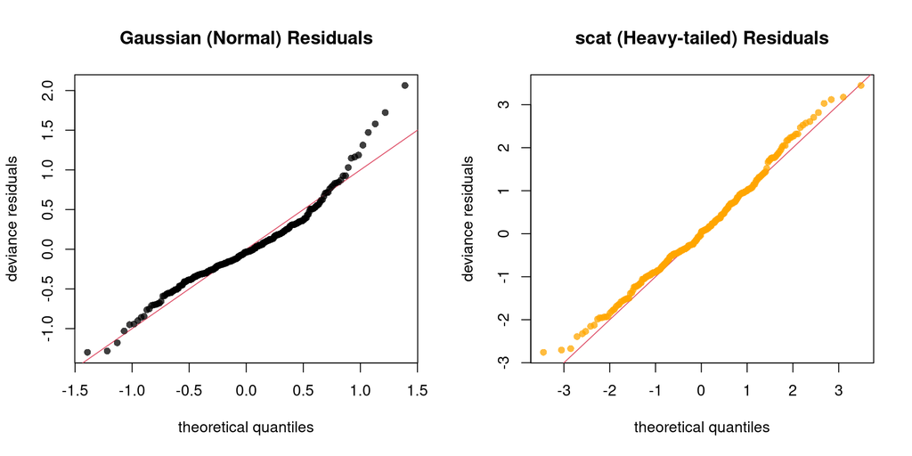

Figure 5

### **Results models comparison**

We implemented two Generalized Additive Models (GAMs) using the scat() family (scaled $t$-distribution) : individual vs aggregated model.

Table 2: Sensitivity analysis - comparison of individual vs. aggregated modeling approaches

| Model Approach | AIC | Dev. Expl. (%) | Adj. R² | Mean EDF | Significant Smooths | N |
| --- | --- | --- | --- | --- | --- | --- |
| Individual | 19193.622 | 2.117 | 0.022 | 2.798 | 4 / 8 | 6828 |
| Aggregated | 364.413 | 8.451 | 0.011 | 1.790 | 2 / 8 | 278 |

### **Conclusion about the “geometric niche”**

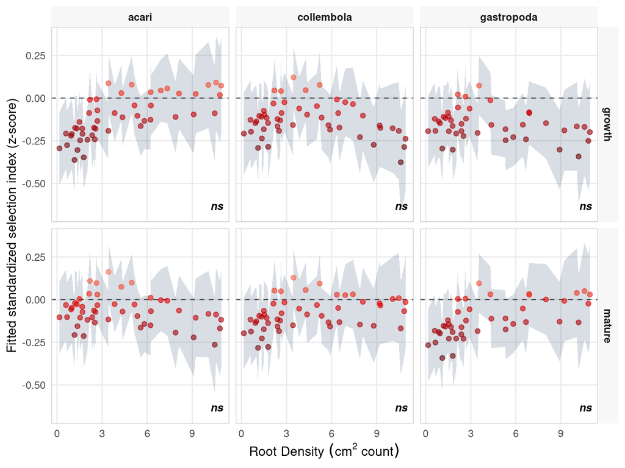

(a) Negative values represent active biological attraction beyond spatial probability

Figure 6: Biological selection vs. geometric constraint

> **Conclusion:** The aggregated model provides a more conservative and honest estimate of the “geometric niche.” It demonstrates that, once individual-level noise is removed, there is no evidence for a strong non-linear selection effect across the root density gradient. Root selection is not merely a byproduct of encountering more roots in dense areas, but a consistent biological signal.

## 3. The selection - demography link : trait or by-product ?

### **Context**

We tested two competing hypotheses to explain the relationship between spatial behavior and population dynamics: a density-driven approach, which tests whether demographic processes dictate spatial behavior, and a performance-based approach, which tests whether the ability to locate and exploit roots leads to population growth.

```r
density_driven_model <- gam(delta.resid ~ Predicted.class.levelup + root_type + s(abundance, by =interaction(Predicted.class.levelup, root_type, drop=TRUE), k=10) + s(scanner, bs="re")+ s(period, bs="re"), family = gaussian(link = "identity"),  method = "REML", select = TRUE, data = habitat_delta)
```

```r
performance_based_model <- gam(abundance ~ Predicted.class.levelup + root_type + s(delta.resid, by = interaction(Predicted.class.levelup, root_type, drop = TRUE), k=5) + s(scanner, bs="re")+ s(period, bs="re"), Gamma(link = "log"), method = "REML", select = TRUE, data = habitat_delta)
```

### **Models diagnostic**

Prior to inference, we performed a multi-step validation to ensure our model structures were appropriate for the data types.

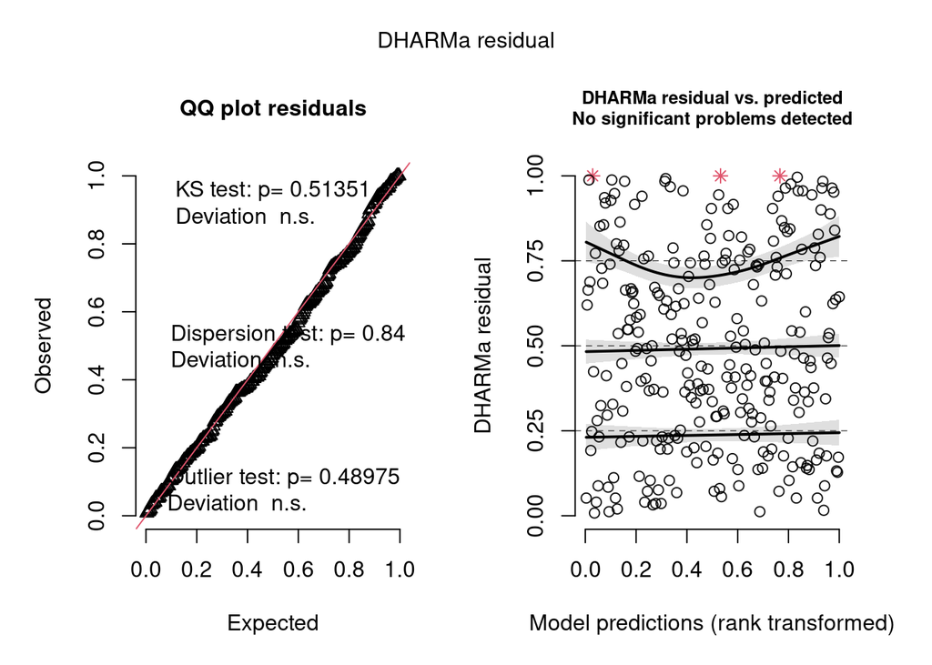

(a) Density-driven Model

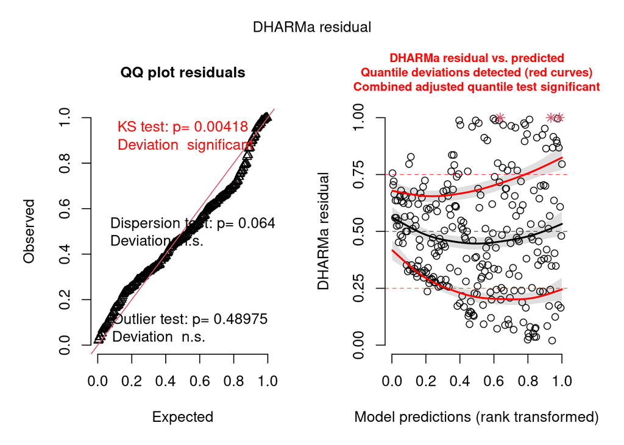

(b) Performance-based Model

Figure 7: Diagnostic plots for (A) density-driven and (B) performance-based models. Left panels show QQ-plots of residuals; right panels show residuals vs. predicted values.

Table 3: Summary of model specifications and convergence diagnostics.

[output not shown]

> **Conclusion:** We accept both models for final interpretation. The performance-based approach provides a strong explanatory framework for success, while the density-driven approach serves as a robust “null-effect” test for density-dependence.

### **Models results**

“To isolate the biological signal from environmental noise, we partitioned the deviance explained into **marginal** $D^2$ (fixed biological predictors) and **random** $D^2$ (stochastic variation from scanner and period). We prioritized $D^2$ over the traditional $R^2$ as it provides a more accurate measure of fit for the likelihood-based framework of GAMs.

We compared our full models against “null” (random effects only) models to isolate three specific components of variation:

1. Total deviance ($D^2_{Total}$): The proportion of null deviance explained by the full model specification, including fixed factors, smooth terms, and random effects.
2. Random effect deviance ($D^2_{Random}$): Extracted from a reduced model containing only the random intercepts (`scanner` and `period`) and parametric fixed factors (`Predicted.class.levelup` and `root_type`). It must represent the background variation inherent to the experimental design.
3. Marginal deviance ($D^2_{Marginal}$): Calculated as $D^2_{Total} - D^2_{Random}$. This value represents the specific explanatory power gained by including the smoothed biological predictors.

Table 4: Final synthesis of model performance and deviance partitioning

| Hypothesis | Family | Deviance Partitioning (D²) Total D² | Deviance Partitioning (D²) Marginal D² | Deviance Partitioning (D²) Random D² | Fit Statistics Adj. R² | Fit Statistics AIC |
| --- | --- | --- | --- | --- | --- | --- |
| Density-driven | gaussian | 0.7% | 0.5% | 0.2% | -0.006 | 894.070 |
| Performance-based | Gamma | 41.7% | 9.5% | 32.1% | 0.276 | 364.816 |

> **Conclusion:** We accept both models for final interpretation. The performance-based approach provides a strong explanatory framework for success, while the density-driven approach serves as a robust “null-effect” test for density.

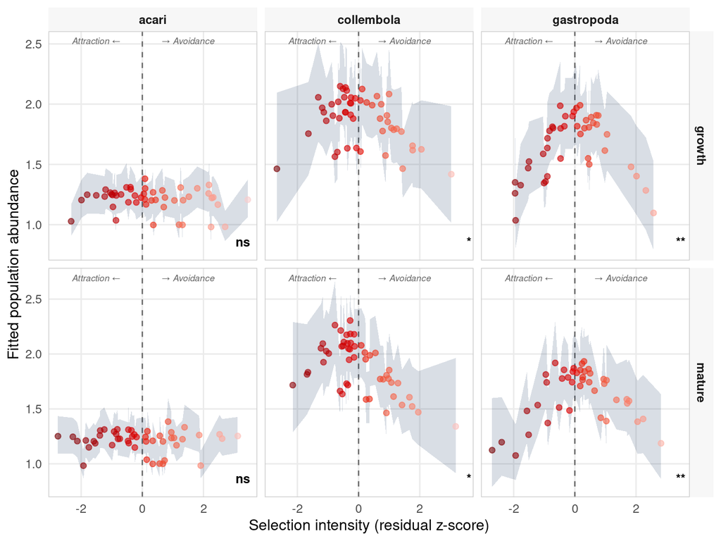

Figure 8: Demographic response to root selection intensity